# ABCD day-of-year and cognition

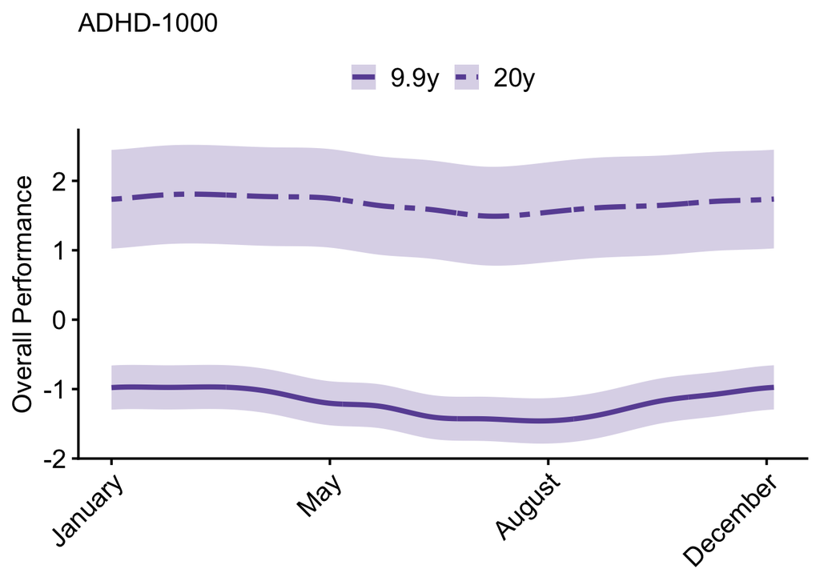

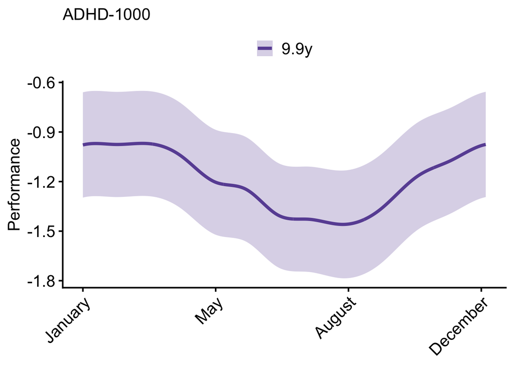

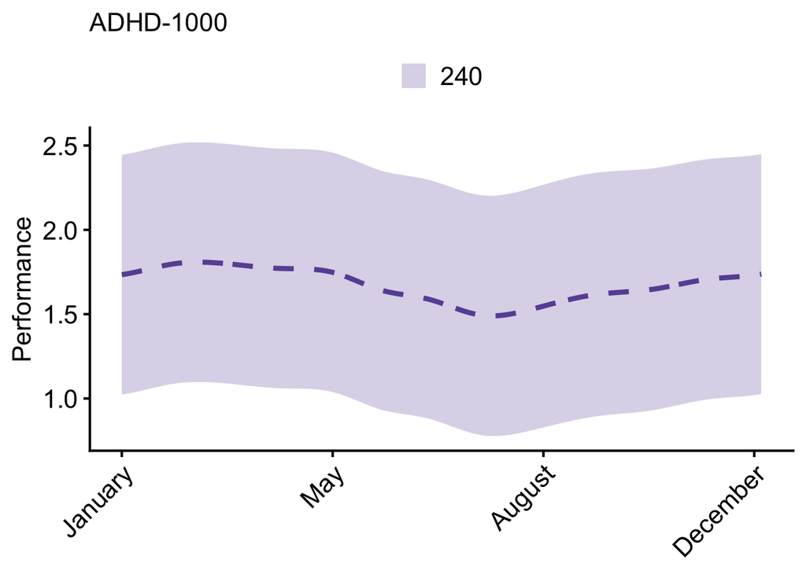

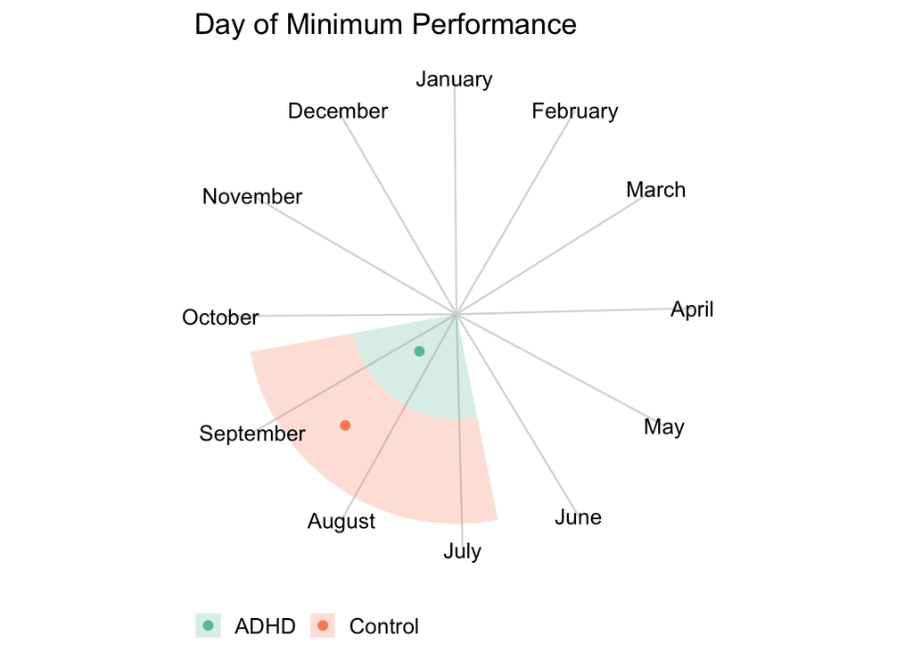

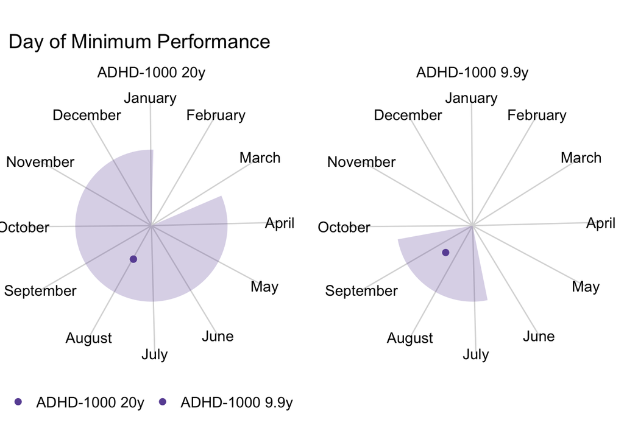

# GUSTO

| **Characteristic** | **N = 532**<sup>1</sup> |
| --- | --- |
| age | 7.42 (7.34, 7.52) |
| Unknown | 190 |
| sex |  |
| M | 184 (54%) |
| F | 158 (46%) |
| Unknown | 190 |

<sup>1</sup> Median (Q1, Q3); n (%)

## GUSTO Cognitive scores

Repeat the analysis for GUSTO data from Singapore.  
I am conceptualizing this simply as evidence that Semptember is not universally the time of worst performance. This is evidence toward the idea of school year mattering.

### All WASI scores

| cogtest | term | N | edf | ref.df | statistic | p.value | pfdr |
| --- | --- | --- | --- | --- | --- | --- | --- |
| Matrix.Reasoning.t.score | s(doy) | 342 | 2.9235631 | 50 | 0.1741043 | 0.0184257 | 0.0368515 |
| Block.Design.t.score | s(doy) | 342 | 0.0112191 | 50 | 0.0002023 | 0.4112642 | 0.4112642 |

#### Plot WASI results

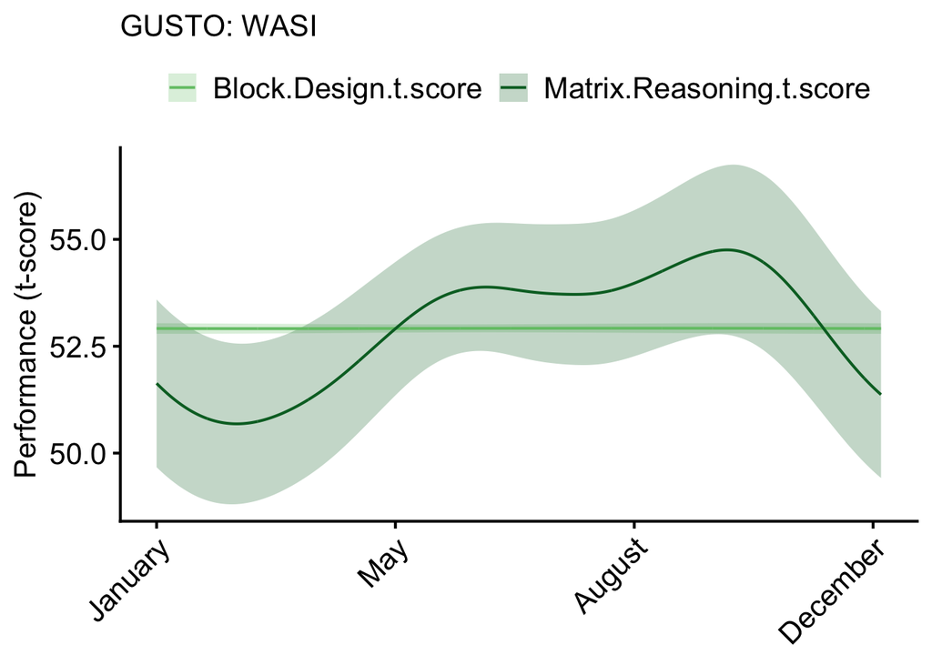

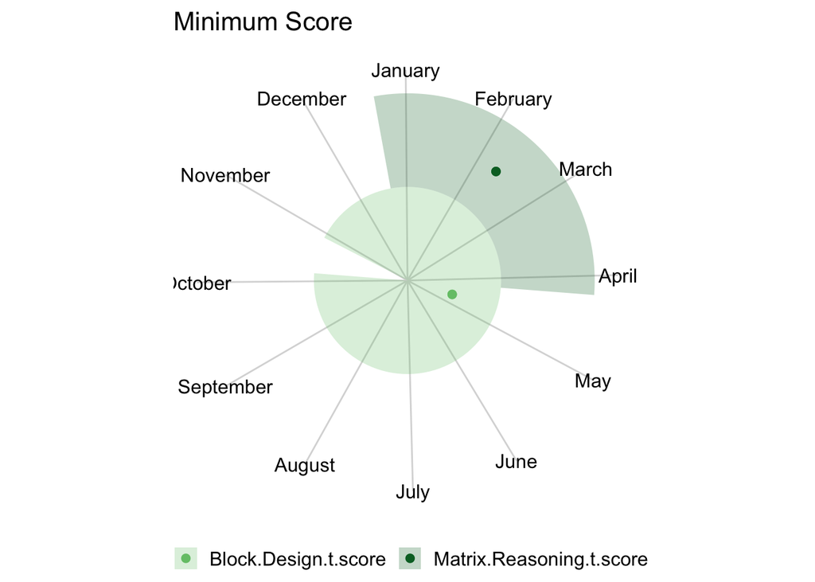

# Combined fig across datasets (GUSTO, PNC, ADHD1000 and ABCD)

## Demographic table

Demographics

| **Characteristic** | **ABCD** N = 11,040 | **PNC** N = 9,416 | **ADHD-1000** N = 2,453 | **GUSTO** N = 342 |
| --- | --- | --- | --- | --- |
| Age (y), Mean (SD) | 9.9 (0.6) | 14.2 (3.7) | 11.8 (2.9) | 7.4 (0.1) |
| Sex, n (%) |  |  |  |  |
| Female | 5,288 (48) | 4,871 (52) | 931 (38) | 158 (46) |
| Male | 5,752 (52) | 4,545 (48) | 1,522 (62) | 184 (54) |

| Sample | Factor | N | edf | partialr2 | p.value | pfdr |
| --- | --- | --- | --- | --- | --- | --- |
| ABCD Total | General Cognition | 11040 | 8.5853588 | 0.0258947 | 0.0000000 | 0.0000000 |
| ABCD Total | Executive Function | 11040 | 5.6054647 | 0.0143190 | 0.0000000 | 0.0000000 |
| ABCD Total | Learning/Memory | 11040 | 4.4336733 | 0.0130297 | 0.0000000 | 0.0000000 |
| ABCD Split 1 | General Cognition | 5366 | 6.0063928 | 0.0263669 | 0.0000101 | 0.0000202 |
| ABCD Split 1 | Executive Function | 5366 | 2.2212735 | 0.0157344 | 0.0174287 | 0.0174287 |
| ABCD Split 1 | Learning/Memory | 5366 | 3.8975517 | 0.0226213 | 0.0000002 | 0.0000005 |
| ABCD Split 2 | General Cognition | 5320 | 3.2003912 | 0.0303138 | 0.0000251 | 0.0000502 |
| ABCD Split 2 | Executive Function | 5320 | 3.1315515 | 0.0168634 | 0.0000004 | 0.0000011 |
| ABCD Split 2 | Learning/Memory | 5320 | 2.8850103 | 0.0118939 | 0.0008706 | 0.0008706 |
| PNC | Social_s(doy) | 9416 | 0.0088256 | 0.0055442 | 0.4442362 | 0.4442362 |
| PNC | Social_ti(age,doy) | 9416 | 13.0830761 | 0.0055442 | 0.0000032 | 0.0000291 |
| PNC | Complex_s(doy) | 9416 | 1.1356844 | 0.0049108 | 0.1293539 | 0.2587077 |
| PNC | Complex_ti(age,doy) | 9416 | 10.9243588 | 0.0049108 | 0.0000105 | 0.0000842 |
| PNC | Executive_s(doy) | 9416 | 3.9826001 | 0.0054595 | 0.0003749 | 0.0022494 |
| PNC | Executive_ti(age,doy) | 9416 | 7.4988913 | 0.0054595 | 0.0007222 | 0.0036110 |
| PNC | Memory_s(doy) | 9416 | 2.3608617 | 0.0046590 | 0.0010400 | 0.0041598 |
| PNC | Memory_ti(age,doy) | 9416 | 7.5407454 | 0.0046590 | 0.0001834 | 0.0012840 |
| PNC | Overall_s(doy) | 9416 | 2.5607255 | 0.0068493 | 0.0094973 | 0.0284920 |
| PNC | Overall_ti(age,doy) | 9416 | 11.9006157 | 0.0068493 | 0.0000008 | 0.0000077 |
| ADHD-1000 | Overall_s(doy) | 1096 | 2.3349253 | 0.0341466 | 0.0125599 | 0.0125599 |
| ADHD-1000 | Overall_ti(interview_age,doy) | 1096 | 9.4603264 | 0.0341466 | 0.0208377 | 0.0208377 |
| GUSTO | Matrix.Reasoning.t.score | 342 | 2.9235631 | 0.0334426 | 0.0184257 | 0.0368515 |
| GUSTO | Block.Design.t.score | 342 | 0.0112191 | 0.0000591 | 0.4112642 | 0.4112642 |

## DOY densities

Supplemental figure.  
This figure shows the density of visit days across the year for each dataset. This is a way to visualize the distribution of visits across the year.

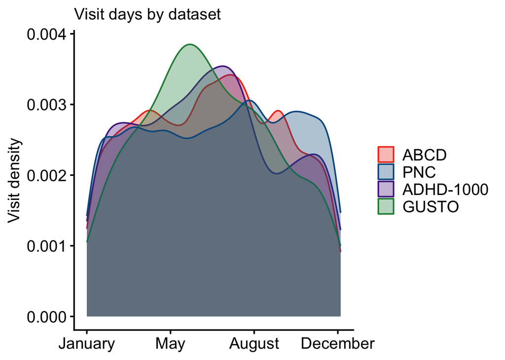

## Circle plots

Figure 4. This figure shows the day of minimum performance for all datasets.

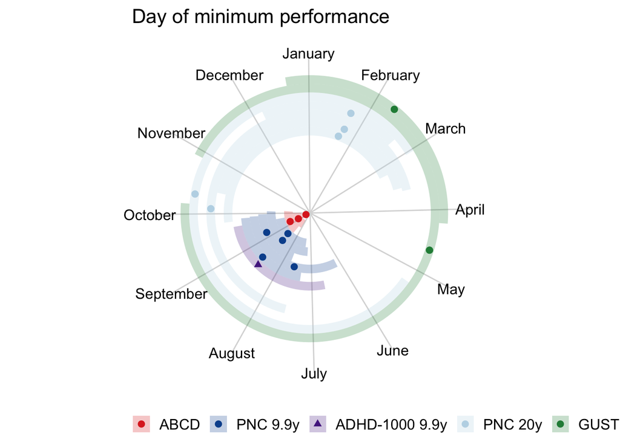

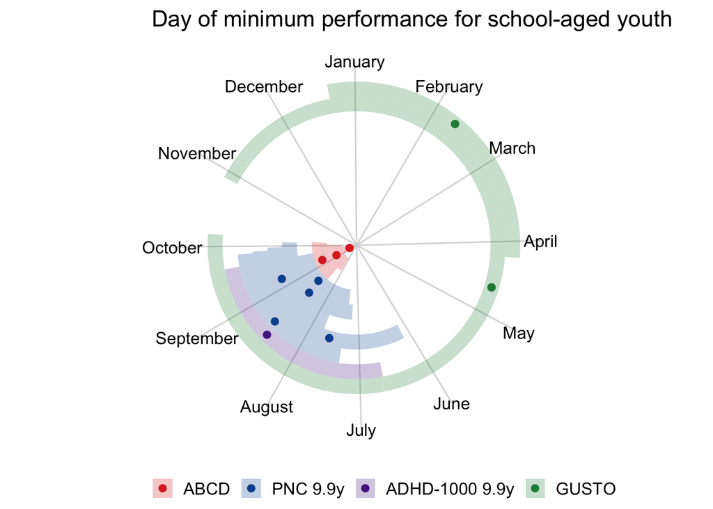

# Exposome

Look at exposome relationships with doy and cognition.

## ABCD

### General exposome (factor 1).

Is there a day-of-year*SES interaction? (Is the day of year effect moderated by SES?)

```
## # A tibble: 6 × 5
##   term                   edf ref.df statistic p.value
##   <chr>                <dbl>  <dbl>     <dbl>   <dbl>
## 1 s(weekdaynum)        0.231   5       0.0518 0.320
## 2 s(doy)               2.93   50       0.261  0.00151
## 3 s(General_SES)       1.74    2.13 1869.     0
## 4 ti(doy,General_SES)  1.28  150       0.0166 0.116
## 5 s(age)               2.79    3.46  260.     0
## 6 s(doy,abcd_site)    35.3    41.3    13.1    0
```

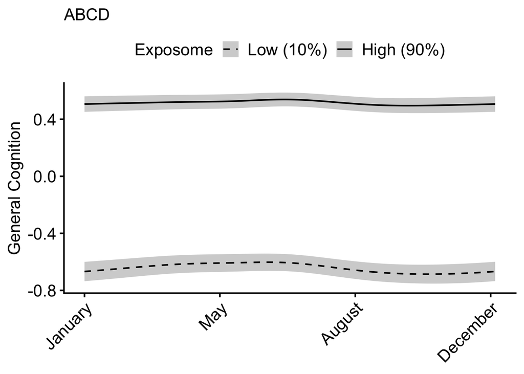

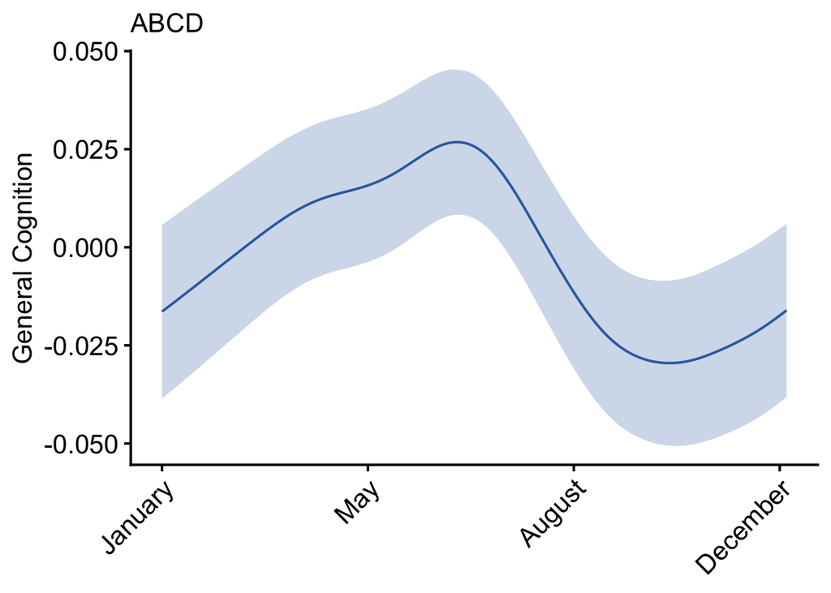

### Does SES of participants relate to day of participation?

```
##
## Family: gaussian
## Link function: identity
##
## Formula:
## General_SES ~ s(weekdaynum, bs = "cc", k = 7) + s(doy, bs = "cc",
##     k = 52) + s(neurocog_pc1.bl) + s(age) + s(doy, abcd_site,
##     bs = "fs", xt = list(bs = "cc", k = 26)) + osex
##
## Parametric coefficients:
##             Estimate Std. Error t value Pr(>|t|)
## (Intercept) -0.02723    0.09281  -0.293    0.769
## osex.L       0.06229    0.01027   6.066 1.36e-09 ***
## ---
## Signif. codes:  0 '***' 0.001 '**' 0.01 '*' 0.05 '.' 0.1 ' ' 1
##
## Approximate significance of smooth terms:
##                       edf  Ref.df       F p-value
## s(weekdaynum)       0.954   5.000   0.323   0.169
## s(doy)              5.089  50.000   0.537  <2e-16 ***
## s(neurocog_pc1.bl)  6.726   7.884 546.083  <2e-16 ***
## s(age)              1.174   1.326 113.697  <2e-16 ***
## s(doy,abcd_site)   59.768 195.000  16.369  <2e-16 ***
## ---
## Signif. codes:  0 '***' 0.001 '**' 0.01 '*' 0.05 '.' 0.1 ' ' 1
##
## R-sq.(adj) =  0.473   Deviance explained = 47.6%
## fREML =  12714  Scale est. = 0.57412   n = 11038
```

```
## [1] 0.02090322
```

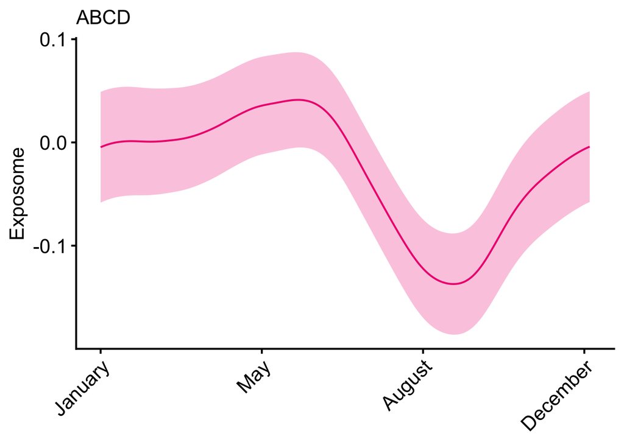

Does doy survive when covarying for exposome?

```
##
## Family: gaussian
## Link function: identity
##
## Formula:
## neurocog_pc1.bl ~ s(weekdaynum, bs = "cc", k = 7) + s(doy, bs = "cc",
##     k = 52) + s(General_SES) + s(age) + s(doy, abcd_site, bs = "fs",
##     xt = list(bs = "cc", k = 26)) + osex
##
## Parametric coefficients:
##              Estimate Std. Error t value Pr(>|t|)
## (Intercept)  0.004389   0.027919   0.157    0.875
## osex.L      -0.067093   0.008343  -8.042 9.78e-16 ***
## ---
## Signif. codes:  0 '***' 0.001 '**' 0.01 '*' 0.05 '.' 0.1 ' ' 1
##
## Approximate significance of smooth terms:
##                      edf  Ref.df        F  p-value
## s(weekdaynum)     0.2667   5.000    0.061 0.311793
## s(doy)            2.7753  50.000    0.162 0.000548 ***
## s(General_SES)    1.8595   2.357 1708.850  < 2e-16 ***
## s(age)            2.7442   3.401  262.802  < 2e-16 ***
## s(doy,abcd_site) 42.0416 195.000    2.643  < 2e-16 ***
## ---
## Signif. codes:  0 '***' 0.001 '**' 0.01 '*' 0.05 '.' 0.1 ' ' 1
##
## R-sq.(adj) =  0.371   Deviance explained = 37.4%
## fREML =  10408  Scale est. = 0.38139   n = 11038
```

```
## # Effect Size for ANOVA (Type III)
##
## Component    |        Parameter | Eta2 (partial) |       95% CI
## ---------------------------------------------------------------
## conditional  |             osex |       5.85e-03 | [0.00, 1.00]
## smooth_terms |    s(weekdaynum) |       2.78e-05 | [0.00, 1.00]
## smooth_terms |           s(doy) |       7.36e-04 | [0.00, 1.00]
## smooth_terms |   s(General_SES) |           0.27 | [0.26, 1.00]
## smooth_terms |           s(age) |           0.08 | [0.07, 1.00]
## smooth_terms | s(doy,abcd_site) |           0.04 | [0.02, 1.00]
##
## - One-sided CIs: upper bound fixed at [1.00].
```

```
## # Effect Size for ANOVA (Type III)
##
## Component    |        Parameter | Cohen's f2 (partial) |      95% CI
## --------------------------------------------------------------------
## conditional  |             osex |             5.89e-03 | [0.00, Inf]
## smooth_terms |    s(weekdaynum) |             2.78e-05 | [0.00, Inf]
## smooth_terms |           s(doy) |             7.37e-04 | [0.00, Inf]
## smooth_terms |   s(General_SES) |                 0.37 | [0.35, Inf]
## smooth_terms |           s(age) |                 0.08 | [0.07, Inf]
## smooth_terms | s(doy,abcd_site) |                 0.05 | [0.02, Inf]
##
## - One-sided CIs: upper bound fixed at [Inf].
```

```
## [1] 0.007246058
```

```
## [1] 0.259663
```

```
##
## Family: gaussian
## Link function: identity
##
## Formula:
## neurocog_pc1.bl ~ s(weekdaynum, bs = "cc", k = 7) + s(doy, bs = "cc",
##     k = 52) + s(General_SES, k = 4) + s(School, k = 4) + s(Family_Values,
##     k = 4) + s(Family_Turmoil, k = 4) + s(Dense_Urban_Poverty,
##     k = 4) + s(Extracurriculars, k = 4) + s(Screen_Time, k = 4) +
##     s(age) + s(doy, abcd_site, bs = "fs", xt = list(bs = "cc",
##     k = 26)) + osex
##
## Parametric coefficients:
##              Estimate Std. Error t value Pr(>|t|)
## (Intercept)  0.002355   0.028072   0.084    0.933
## osex.L      -0.065893   0.008486  -7.765 8.91e-15 ***
## ---
## Signif. codes:  0 '***' 0.001 '**' 0.01 '*' 0.05 '.' 0.1 ' ' 1
##
## Approximate significance of smooth terms:
##                            edf  Ref.df        F  p-value
## s(weekdaynum)           0.2934   5.000    0.068 0.307797
## s(doy)                  2.7861  50.000    0.162 0.000688 ***
## s(General_SES)          2.2121   2.611 1362.874  < 2e-16 ***
## s(School)               2.5079   2.835    4.703 0.002194 **
## s(Family_Values)        2.3949   2.762   18.307  < 2e-16 ***
## s(Family_Turmoil)       2.2342   2.627    1.935 0.092204 .
## s(Dense_Urban_Poverty)  1.6177   1.988    3.439 0.040728 *
## s(Extracurriculars)     2.7164   2.942    8.979 5.58e-06 ***
## s(Screen_Time)          1.0001   1.000   38.632  < 2e-16 ***
## s(age)                  2.8089   3.481  268.127  < 2e-16 ***
## s(doy,abcd_site)       41.2361 195.000    2.535  < 2e-16 ***
## ---
## Signif. codes:  0 '***' 0.001 '**' 0.01 '*' 0.05 '.' 0.1 ' ' 1
##
## R-sq.(adj) =  0.379   Deviance explained = 38.3%
## fREML =  10363  Scale est. = 0.37629   n = 11038
```

```
## # Effect Size for ANOVA (Type III)
##
## Component    |              Parameter | Eta2 (partial) |       95% CI
## ---------------------------------------------------------------------
## conditional  |                   osex |       5.46e-03 | [0.00, 1.00]
## smooth_terms |          s(weekdaynum) |       3.09e-05 | [0.00, 1.00]
## smooth_terms |                 s(doy) |       7.36e-04 | [0.00, 1.00]
## smooth_terms |         s(General_SES) |           0.24 | [0.23, 1.00]
## smooth_terms |              s(School) |       1.21e-03 | [0.00, 1.00]
## smooth_terms |       s(Family_Values) |       4.59e-03 | [0.00, 1.00]
## smooth_terms |      s(Family_Turmoil) |       4.63e-04 | [0.00, 1.00]
## smooth_terms | s(Dense_Urban_Poverty) |       6.23e-04 | [0.00, 1.00]
## smooth_terms |    s(Extracurriculars) |       2.40e-03 | [0.00, 1.00]
## smooth_terms |         s(Screen_Time) |       3.51e-03 | [0.00, 1.00]
## smooth_terms |                 s(age) |           0.08 | [0.07, 1.00]
## smooth_terms |       s(doy,abcd_site) |           0.04 | [0.02, 1.00]
##
## - One-sided CIs: upper bound fixed at [1.00].
```

```
## # Effect Size for ANOVA (Type III)
##
## Component    |              Parameter | Cohen's f2 (partial) |      95% CI
## --------------------------------------------------------------------------
## conditional  |                   osex |             5.49e-03 | [0.00, Inf]
## smooth_terms |          s(weekdaynum) |             3.09e-05 | [0.00, Inf]
## smooth_terms |                 s(doy) |             7.36e-04 | [0.00, Inf]
## smooth_terms |         s(General_SES) |                 0.32 | [0.31, Inf]
## smooth_terms |              s(School) |             1.21e-03 | [0.00, Inf]
## smooth_terms |       s(Family_Values) |             4.61e-03 | [0.00, Inf]
## smooth_terms |      s(Family_Turmoil) |             4.63e-04 | [0.00, Inf]
## smooth_terms | s(Dense_Urban_Poverty) |             6.23e-04 | [0.00, Inf]
## smooth_terms |    s(Extracurriculars) |             2.41e-03 | [0.00, Inf]
## smooth_terms |         s(Screen_Time) |             3.52e-03 | [0.00, Inf]
## smooth_terms |                 s(age) |                 0.09 | [0.08, Inf]
## smooth_terms |       s(doy,abcd_site) |                 0.05 | [0.02, Inf]
##
## - One-sided CIs: upper bound fixed at [Inf].
```

```
## [1] 0.006821925
```

#### Does DOY survive when propensity matching on exposome scores?

```
##
## Call:
## glm(formula = end_of_summer_vs_spring ~ General_SES + age + osex +
##     School + Family_Values + Family_Turmoil + Dense_Urban_Poverty +
##     Extracurriculars + Screen_Time, family = binomial, data = abcd.df.sub)
##
## Coefficients:
##                       Estimate Std. Error z value Pr(>|z|)
## (Intercept)          0.3409498  0.6242006   0.546  0.58492
## General_SES         -0.2813418  0.0367699  -7.651 1.99e-14 ***
## age                 -0.0004893  0.0001719  -2.846  0.00443 **
## osex.L              -0.0678143  0.0558126  -1.215  0.22435
## School               0.2278497  0.0419828   5.427 5.72e-08 ***
## Family_Values       -0.0465430  0.0433215  -1.074  0.28266
## Family_Turmoil      -0.0392114  0.0415123  -0.945  0.34488
## Dense_Urban_Poverty  0.0772774  0.0332517   2.324  0.02012 *
## Extracurriculars    -0.0631871  0.0526070  -1.201  0.22971
## Screen_Time          0.0523516  0.0570463   0.918  0.35877
## ---
## Signif. codes:  0 '***' 0.001 '**' 0.01 '*' 0.05 '.' 0.1 ' ' 1
##
## (Dispersion parameter for binomial family taken to be 1)
##
##     Null deviance: 4371.5  on 4523  degrees of freedom
## Residual deviance: 4250.5  on 4514  degrees of freedom
## AIC: 4270.5
##
## Number of Fisher Scoring iterations: 4
```

```
##
## Family: gaussian
## Link function: identity
##
## Formula:
## neurocog_pc1.bl ~ end_of_summer_vs_spring + s(age) + osex + s(abcd_site,
##     bs = "re") + s(weekdaynum, bs = "cc", k = 7) + General_SES +
##     School + Family_Values + Family_Turmoil + Dense_Urban_Poverty +
##     Extracurriculars + Screen_Time
##
## Parametric coefficients:
##                                       Estimate Std. Error t value Pr(>|t|)
## (Intercept)                          -0.009957   0.040988  -0.243   0.8081
## end_of_summer_vs_springEnd of Summer -0.074654   0.030232  -2.469   0.0136 *
## osex.L                               -0.054933   0.021579  -2.546   0.0110 *
## General_SES                           0.393536   0.015843  24.840   <2e-16 ***
## School                               -0.033789   0.016515  -2.046   0.0409 *
## Family_Values                        -0.033359   0.016600  -2.010   0.0446 *
## Family_Turmoil                       -0.013521   0.016362  -0.826   0.4087
## Dense_Urban_Poverty                   0.008587   0.016772   0.512   0.6087
## Extracurriculars                      0.010329   0.020028   0.516   0.6061
## Screen_Time                          -0.038015   0.022479  -1.691   0.0910 .
## ---
## Signif. codes:  0 '***' 0.001 '**' 0.01 '*' 0.05 '.' 0.1 ' ' 1
##
## Approximate significance of smooth terms:
##                     edf Ref.df       F p-value
## s(age)        1.000e+00      1 118.750  <2e-16 ***
## s(abcd_site)  1.471e+01     21   2.742  <2e-16 ***
## s(weekdaynum) 2.767e-05      5   0.000    0.53
## ---
## Signif. codes:  0 '***' 0.001 '**' 0.01 '*' 0.05 '.' 0.1 ' ' 1
##
## R-sq.(adj) =  0.382   Deviance explained = 39.1%
## fREML =   1615  Scale est. = 0.37237   n = 1700
```

```
## # Effect Size for ANOVA (Type III)
##
## Component    |               Parameter | Eta2 (partial) |       95% CI
## ----------------------------------------------------------------------
## conditional  | end_of_summer_vs_spring |       3.63e-03 | [0.00, 1.00]
## conditional  |                    osex |       3.86e-03 | [0.00, 1.00]
## conditional  |             General_SES |           0.27 | [0.24, 1.00]
## conditional  |                  School |       2.49e-03 | [0.00, 1.00]
## conditional  |           Family_Values |       2.41e-03 | [0.00, 1.00]
## conditional  |          Family_Turmoil |       4.08e-04 | [0.00, 1.00]
## conditional  |     Dense_Urban_Poverty |       1.57e-04 | [0.00, 1.00]
## conditional  |        Extracurriculars |       1.59e-04 | [0.00, 1.00]
## conditional  |             Screen_Time |       1.71e-03 | [0.00, 1.00]
## smooth_terms |                  s(age) |           0.07 | [0.05, 1.00]
## smooth_terms |            s(abcd_site) |           0.03 | [0.01, 1.00]
## smooth_terms |           s(weekdaynum) |       1.09e-08 | [0.00, 1.00]
##
## - One-sided CIs: upper bound fixed at [1.00].
```

```
## # Effect Size for ANOVA (Type III)
##
## Component    |               Parameter | Cohen's f2 (partial) |      95% CI
## ---------------------------------------------------------------------------
## conditional  | end_of_summer_vs_spring |             3.64e-03 | [0.00, Inf]
## conditional  |                    osex |             3.87e-03 | [0.00, Inf]
## conditional  |             General_SES |                 0.37 | [0.32, Inf]
## conditional  |                  School |             2.50e-03 | [0.00, Inf]
## conditional  |           Family_Values |             2.41e-03 | [0.00, Inf]
## conditional  |          Family_Turmoil |             4.08e-04 | [0.00, Inf]
## conditional  |     Dense_Urban_Poverty |             1.57e-04 | [0.00, Inf]
## conditional  |        Extracurriculars |             1.59e-04 | [0.00, Inf]
## conditional  |             Screen_Time |             1.71e-03 | [0.00, Inf]
## smooth_terms |                  s(age) |                 0.07 | [0.05, Inf]
## smooth_terms |            s(abcd_site) |                 0.03 | [0.01, Inf]
## smooth_terms |           s(weekdaynum) |             1.09e-08 | [0.00, Inf]
##
## - One-sided CIs: upper bound fixed at [Inf].
```

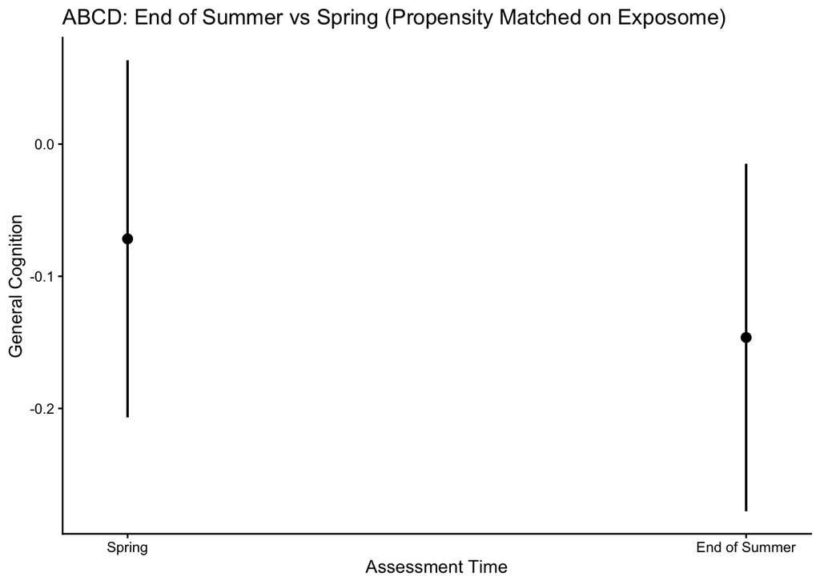

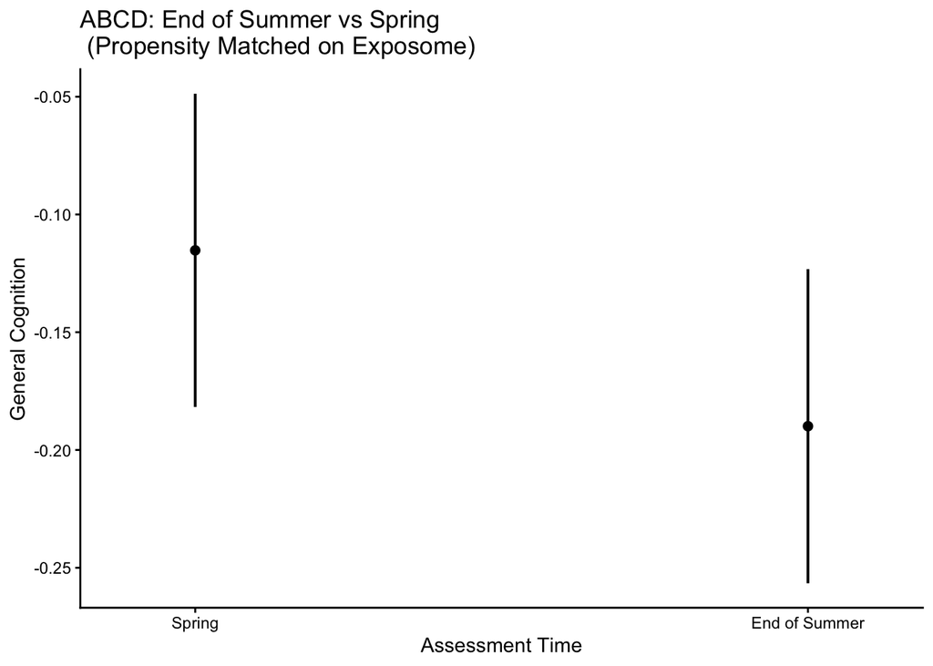

#### Test general exposome with all cognitive factors and FDR

| Exposome | cog.measure | term | N | edf | p.value | pfdr |
| --- | --- | --- | --- | --- | --- | --- |
| General_SES | neurocog_pc2.bl | ti(doy,Exposome.value) | 11038 | 5.7541585 | 0.0011614 | 0.0034843 |
| General_SES | neurocog_pc1.bl | ti(doy,Exposome.value) | 11038 | 1.3210911 | 0.1090933 | 0.2181866 |
| General_SES | neurocog_pc3.bl | ti(doy,Exposome.value) | 11038 | 0.0001429 | 0.7630389 | 0.7630389 |

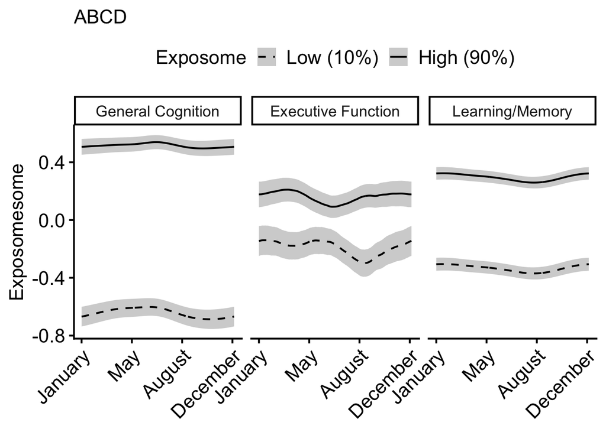

## PNC exposome

#### General exposome.

Is there a day-of-year*SES interaction? (Is the day of year effect moderated by SES?) In this case, since we know there is a doy-by-age interaction, what we really want to know is whether the doy-by-age interaction depends on exposome.

```
##
## Family: gaussian
## Link function: identity
##
## Formula:
## NAR_Overall_Efficiency ~ s(weekdaynum, bs = "cc", k = 7) + s(doy,
##     bs = "cc", k = 52) + s(GeneralExposome, k = 4) + s(age) +
##     ti(doy, GeneralExposome, k = c(52, 4), bs = c("cc", "ts")) +
##     ti(doy, age, k = c(26, 10), bs = c("cc", "ts")) + ti(GeneralExposome,
##     age, k = c(4, 10)) + ti(doy, GeneralExposome, age, k = c(26,
##     4, 10), bs = c("cc", "ts", "ts")) + osex
##
## Parametric coefficients:
##              Estimate Std. Error t value Pr(>|t|)
## (Intercept) -0.056829   0.008175  -6.951 3.86e-12 ***
## osex.L       0.063231   0.011243   5.624 1.92e-08 ***
## ---
## Signif. codes:  0 '***' 0.001 '**' 0.01 '*' 0.05 '.' 0.1 ' ' 1
##
## Approximate significance of smooth terms:
##                                   edf  Ref.df       F  p-value
## s(weekdaynum)               0.0001776   5.000   0.000  0.43166
## s(doy)                      3.0260889  50.000   0.186  0.01278 *
## s(GeneralExposome)          1.0561730   1.110 718.575  < 2e-16 ***
## s(age)                      6.7519520   7.839 655.832  < 2e-16 ***
## ti(doy,GeneralExposome)     0.0004700 150.000   0.000  0.58337
## ti(doy,age)                 7.9117496 216.000   0.131 7.52e-06 ***
## ti(GeneralExposome,age)     1.0001144   1.000  11.753  0.00061 ***
## ti(doy,GeneralExposome,age) 3.5071642 648.000   0.009  0.06920 .
## ---
## Signif. codes:  0 '***' 0.001 '**' 0.01 '*' 0.05 '.' 0.1 ' ' 1
##
## R-sq.(adj) =  0.419   Deviance explained = 42.1%
## fREML =  10885  Scale est. = 0.58673   n = 9416
```

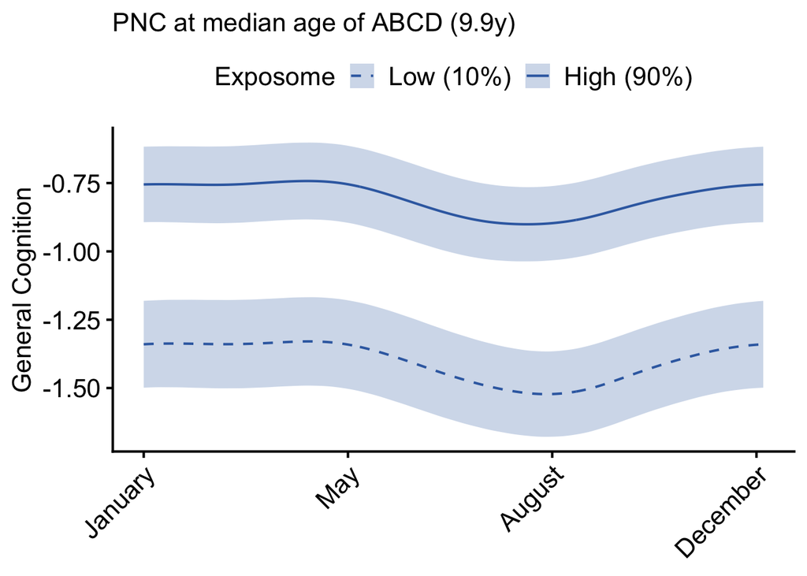

#### Does participation date vary by general adversity?

```
##
## Family: gaussian
## Link function: identity
##
## Formula:
## GeneralExposome ~ s(weekdaynum, bs = "cc", k = 7) + ti(doy, age,
##     k = c(26, 10), bs = c("cc", "ts")) + s(doy, bs = "cc", k = 52) +
##     s(age) + osex
##
## Parametric coefficients:
##              Estimate Std. Error t value Pr(>|t|)
## (Intercept)  0.008647   0.010516   0.822 0.410906
## osex.L      -0.052322   0.014594  -3.585 0.000339 ***
## ---
## Signif. codes:  0 '***' 0.001 '**' 0.01 '*' 0.05 '.' 0.1 ' ' 1
##
## Approximate significance of smooth terms:
##                  edf  Ref.df     F  p-value
## s(weekdaynum)  3.704   5.000 4.194 8.68e-05 ***
## ti(doy,age)   11.105 216.000 0.085  0.01446 *
## s(doy)         4.504  50.000 0.290  0.00358 **
## s(age)         2.887   3.593 6.603 7.55e-05 ***
## ---
## Signif. codes:  0 '***' 0.001 '**' 0.01 '*' 0.05 '.' 0.1 ' ' 1
##
## R-sq.(adj) =  0.00911   Deviance explained = 1.16%
## fREML =  13342  Scale est. = 0.99008   n = 9416
```

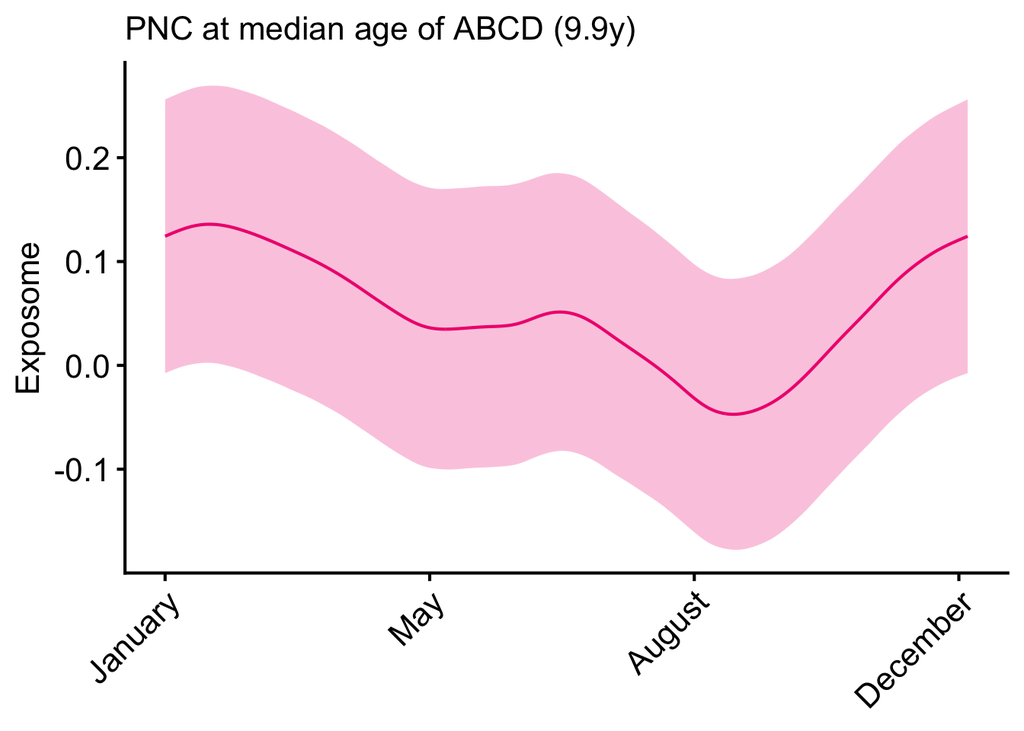

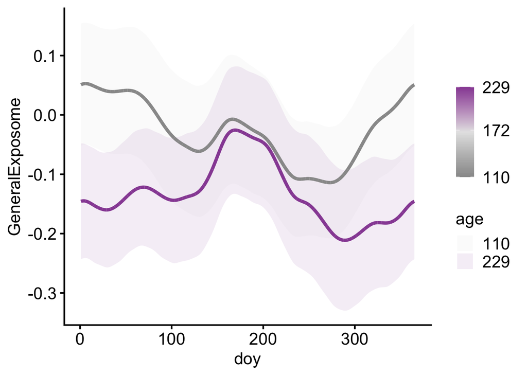

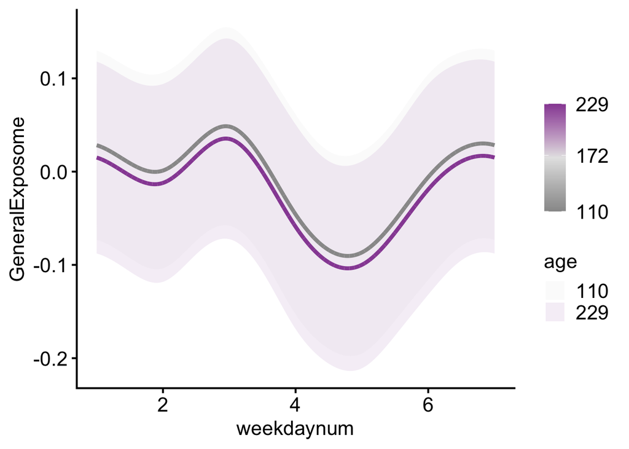

#### All cognitive factors

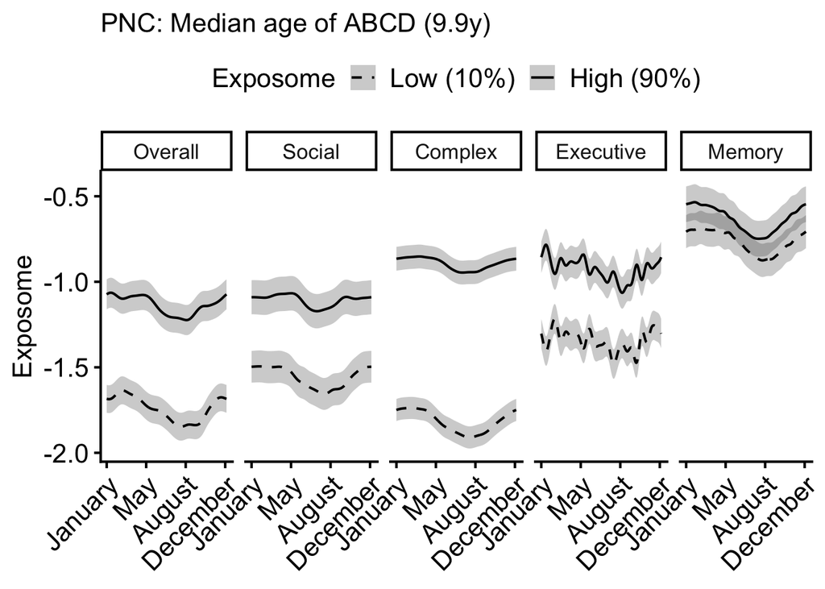

| Exposome | Factor | term | edf | ref.df | statistic | p.value | pfdr |
| --- | --- | --- | --- | --- | --- | --- | --- |
| GeneralExposome | Executive | ti(age,Exposome.value,doy) | 11.886685 | 623 | 0.0398664 | 0.0013353 | 0.0066766 |
| GeneralExposome | Overall | ti(age,Exposome.value,doy) | 11.986435 | 648 | 0.0255274 | 0.0362485 | 0.1449942 |
| GeneralExposome | Social | ti(age,Exposome.value,doy) | 5.590097 | 648 | 0.0125571 | 0.0575275 | 0.1725825 |
| GeneralExposome | Complex | ti(age,Exposome.value,doy) | 4.144218 | 648 | 0.0098128 | 0.0718252 | 0.1725825 |
| GeneralExposome | Memory | ti(age,Exposome.value,doy) | 8.790055 | 648 | 0.0168332 | 0.1221833 | 0.1725825 |

```
##
## Family: gaussian
## Link function: identity
##
## Formula:
## NAR_F3_Executive_Efficiency ~ s(weekdaynum, bs = "cc", k = 7) +
##     s(doy, bs = "cc", k = 52) + s(GeneralExposome, k = 4) + ti(doy,
##     GeneralExposome, k = c(26, 4), bs = c("cc", "ts")) + s(age,
##     k = 10) + ti(doy, age, k = c(26, 10), bs = c("cc", "ts")) +
##     ti(GeneralExposome, age) + ti(doy, GeneralExposome, age,
##     k = c(26, 4, 10), bs = c("cc", "ts", "ts")) + osex
##
## Parametric coefficients:
##              Estimate Std. Error t value Pr(>|t|)
## (Intercept) -0.046737   0.009591  -4.873 1.12e-06 ***
## osex.L       0.014934   0.010632   1.405     0.16
## ---
## Signif. codes:  0 '***' 0.001 '**' 0.01 '*' 0.05 '.' 0.1 ' ' 1
##
## Approximate significance of smooth terms:
##                                   edf  Ref.df       F p-value
## s(weekdaynum)                1.442517   5.000   0.675 0.07652 .
## s(doy)                       3.619358  50.000   0.268 0.00205 **
## s(GeneralExposome)           2.071205   2.468 147.654 < 2e-16 ***
## ti(GeneralExposome,doy)      0.000324  72.000   0.000 0.85149
## s(age)                       6.612475   7.718 748.528 < 2e-16 ***
## ti(age,doy)                  6.725160 216.000   0.070 0.00317 **
## ti(GeneralExposome,age)      6.528507   8.576   2.484 0.00925 **
## ti(age,GeneralExposome,doy) 11.886685 623.000   0.040 0.00134 **
## ---
## Signif. codes:  0 '***' 0.001 '**' 0.01 '*' 0.05 '.' 0.1 ' ' 1
##
## R-sq.(adj) =  0.497   Deviance explained = 49.9%
## fREML =  10364  Scale est. = 0.52388   n = 9416
```

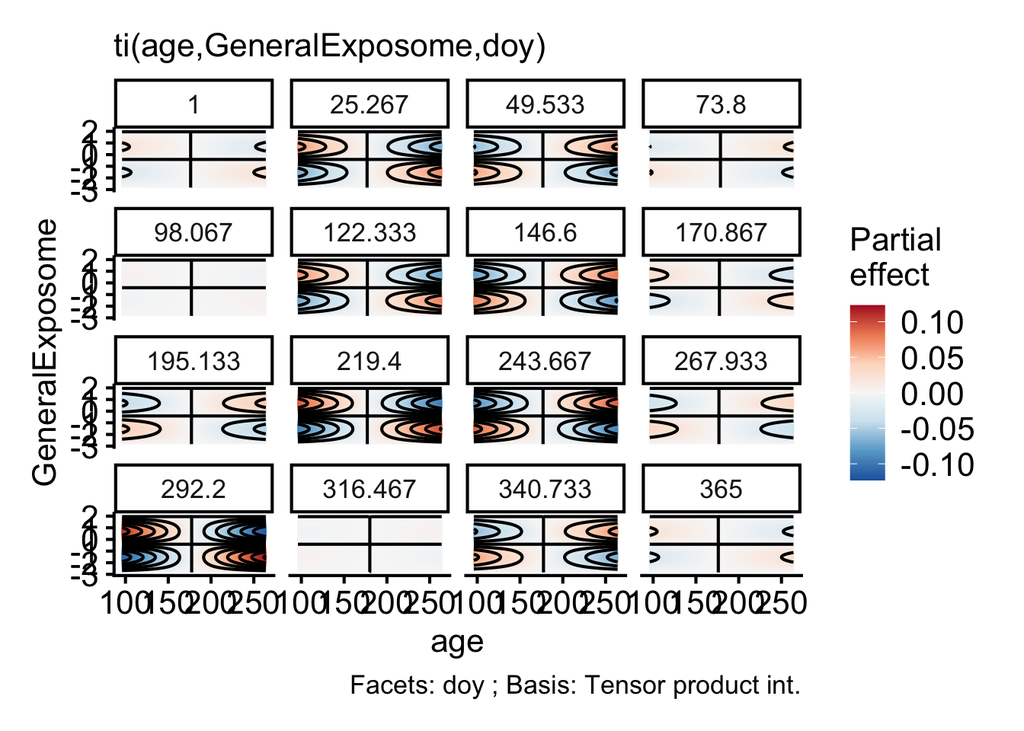

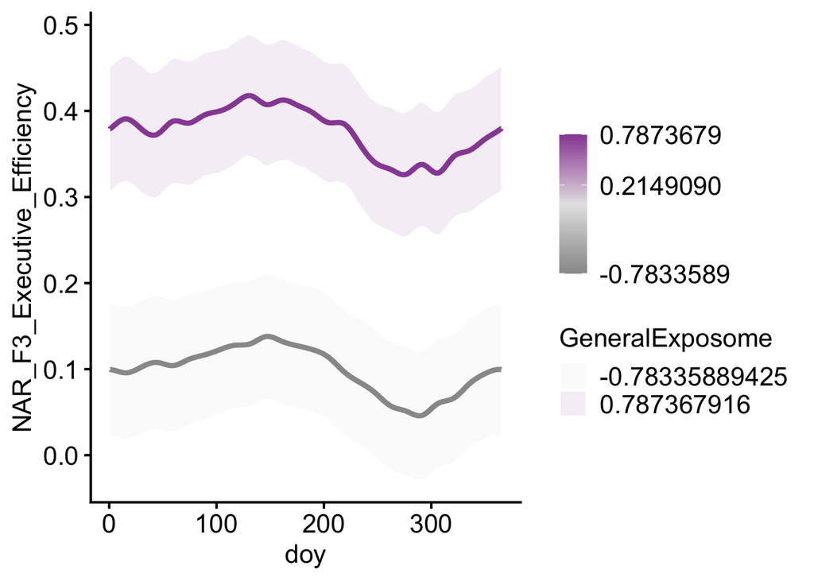

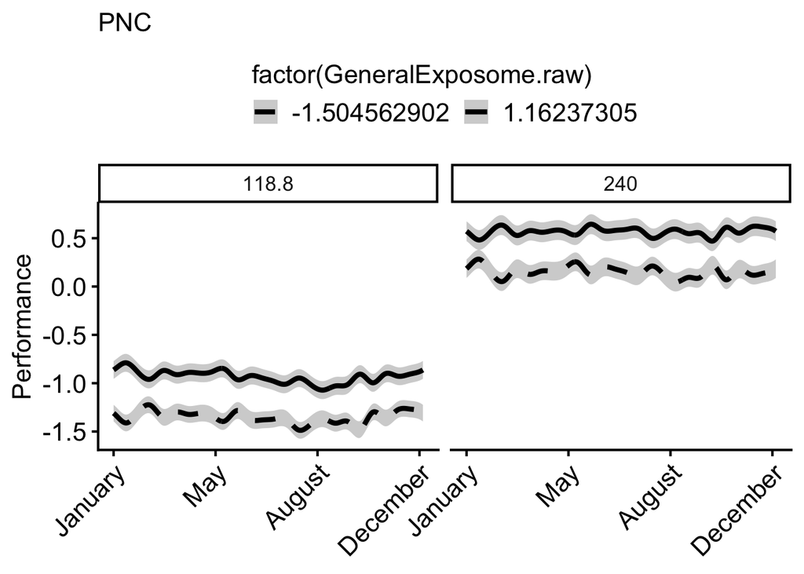

## Generate Figure 5

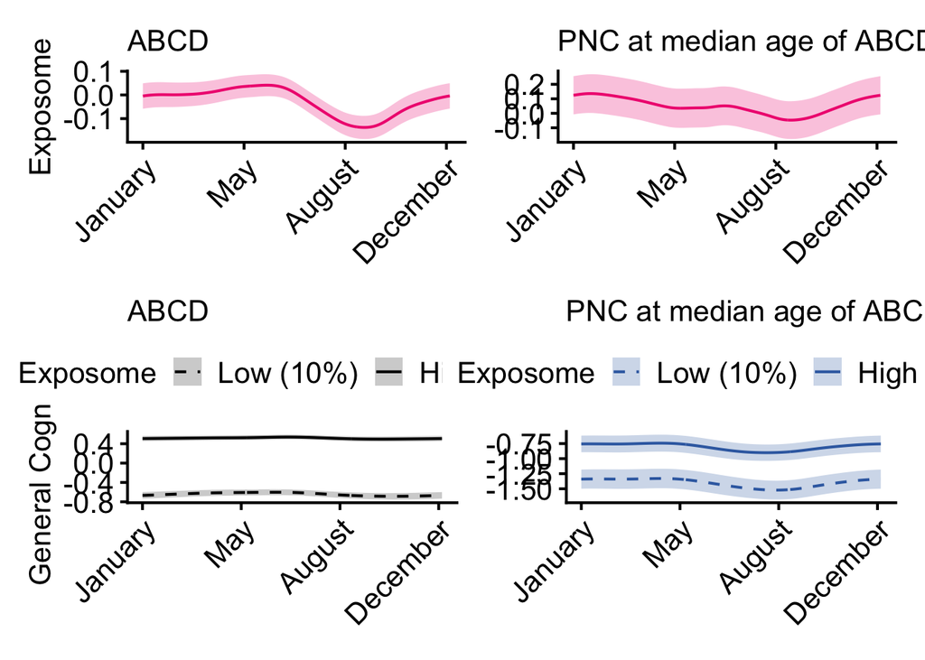

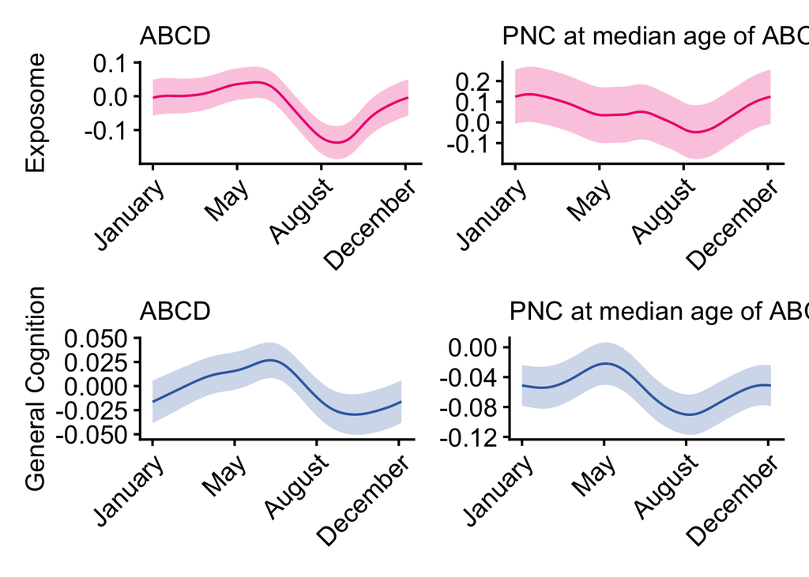

# Winter holiday

In response to reviewer comments.

```
##
## Family: gaussian
## Link function: identity
##
## Formula:
## neurocog_pc1.bl ~ christmas_vs_january + s(age) + osex + s(General_SES,
##     k = 4) + s(abcd_site, bs = "re") + s(weekdaynum, bs = "cc",
##     k = 7)
##
## Parametric coefficients:
##                             Estimate Std. Error t value Pr(>|t|)
## (Intercept)                 -0.06705    0.04048  -1.656   0.0979 .
## christmas_vs_januaryJanuary  0.03252    0.03604   0.902   0.3671
## osex.L                      -0.04777    0.02546  -1.876   0.0609 .
## ---
## Signif. codes:  0 '***' 0.001 '**' 0.01 '*' 0.05 '.' 0.1 ' ' 1
##
## Approximate significance of smooth terms:
##                   edf Ref.df       F p-value
## s(age)          1.475    1.8  51.029  <2e-16 ***
## s(General_SES)  1.000    1.0 448.072  <2e-16 ***
## s(abcd_site)   14.657   20.0   2.867  <2e-16 ***
## s(weekdaynum)   1.297    5.0   0.694  0.0751 .
## ---
## Signif. codes:  0 '***' 0.001 '**' 0.01 '*' 0.05 '.' 0.1 ' ' 1
##
## R-sq.(adj) =  0.369   Deviance explained = 37.9%
## fREML = 1217.6  Scale est. = 0.39416   n = 1249
```